# ANÁLISIS DE LA CORRELACIÓN ENTRE LA INFLACIÓN Y LA PERCEPCIÓN DE CORRUPCIÓN

Rubén Valverde Romero

14 November, 2024

## Introducción

El objetivo principal de este análisis es estudiar la corelación entre la `inflación` y el indice de percepcion de corrupción (`CPI`).

### Obtención de los Datos

Los datos utilizados en este análisis provienen de dos fuentes principales:

- **Inflación**: Los datos de inflación anual por país y región se obtuvieron del [Fondo Monetario Internacional](https://www.imf.org/external/datamapper/NGDP_RPCH@WEO/OEMDC/ADVEC/WEOWORLD).
- **Índice de Percepción de Corrupción (CPI)**: Los datos del CPI se obtuvieron de [transparency.org](https://www.transparency.org/en/), una organización sin fines de lucro que publica anualmente el índice de percepción de corrupción.

Una vez obtenidos los distintos datasets se juntaron basandose en dos columnas distintas, según el caso podía ser el `ISO` o el `nombre` de un país. Con frecuencia la ortografía de un país variaba de uno a otro, los pasos que seguí fueron:

- Creación de 2 arrays con los nombres de los paises
- Creación y de 1 array con los nombres que no coinciden
- En vez de revisarlo manualmente le pase el array a Llama 3.1 varias veces hasta obtener una lista con todos los paises que aparecen en ambos datasets pero con distinto nombre
- Con esa lista se cambia la ortografía del nombre de los paises del segundo dataset a los del primero
- Se realiza un merge con el nombre del país como columna en común.

## Limpieza de datos

### Carga y Visualización del DataFrame

```r
df <- read.csv("inflation_corruption_1995_2023_Ruben_Valverde.csv")
head(df[0:6])
```

```
##       country iso region inflation_2023 score_2023 rank_2023
## 1 Afghanistan AFG     AP        no data         20       162
## 2     Albania ALB    ECA            4.8         37        98
## 3     Algeria DZA   MENA            9.3         36       104
## 4      Angola AGO    SSA           13.6         33       121
## 5   Argentina ARG    AME          133.5         37        98
## 6     Armenia ARM    ECA              2         47        62
```

```r
# Nota: El resto de columnas son repeticiones de las columnas 3, 4 y 5 por lo que mostrarlas no aportan más información y empeoran la estética

summary(df[0:6])
```

```
##    country              iso               region          inflation_2023
##  Length:177         Length:177         Length:177         Length:177
##  Class :character   Class :character   Class :character   Class :character
##  Mode  :character   Mode  :character   Mode  :character   Mode  :character
##
##
##
##    score_2023      rank_2023
##  Min.   :11.00   Min.   :  1.00
##  1st Qu.:29.00   1st Qu.: 42.00
##  Median :40.00   Median : 87.00
##  Mean   :43.54   Mean   : 87.69
##  3rd Qu.:56.00   3rd Qu.:133.00
##  Max.   :90.00   Max.   :180.00
```

### Reemplazo de Valores “no data” por NA

```r
# Contar valores "no data" en cada columna
inflation <- df[, grepl("inflation", names(df))]
no_data_count <- colSums(inflation == "no data", na.rm = TRUE)
print(paste("Hay un total de", sum(no_data_count), "valores 'no data'"))
```

```
## [1] "Hay un total de 128 valores 'no data'"
```

```r
# Reemplazar los valores "no data" por NA en todo el DataFrame porque da problemas al conteo
df[df == "no data"] <- NA
```

### Conversión de Columnas a Numérico

```r
# Convertir las columnas de inflación de 1995 a 2023 a valores numéricos
for (year in 1995:2023) {
  column <- paste("inflation", year, sep = "_")
  df[[column]] <- as.numeric(df[[column]])
}
```

### Conteo de valores NA

```r
# Contar y mostrar el número de valores nulos por columna
print(paste("Hay un total de", sum(is.na(df)), "valores nulos"))
```

```
## [1] "Hay un total de 2152 valores nulos"
```

### Formateo del DataFrame

```r
# Transformar el DataFrame de formato ancho a formato largo para poder analizar los datos de inflación, puntuación y rango a lo largo del tiempo posteriormente
df_melted <- df %>%
  pivot_longer(cols = starts_with("inflation_") | starts_with("score_"),
  names_to = c(".value", "year"),
  names_sep = "_") %>%
select(country, iso, region, year, inflation, score) #Nota el ranking no se llega a utilizar en este análisis asi que lo elimino

# Convertir las columnas 'inflation', 'score' y 'year' a tipo numérico en el DataFrame df_melted
df_melted <- df_melted %>%
    mutate(across(c(inflation, score, year), as.numeric))
    df_melted <- df_melted %>% arrange(year, country)
head(df_melted)
```

```
## # A tibble: 6 × 6
##   country     iso   region  year inflation score
##   <chr>       <chr> <chr>  <dbl>     <dbl> <dbl>
## 1 Afghanistan AFG   AP      1995      NA   NA
## 2 Albania     ALB   ECA     1995       7.8 NA
## 3 Algeria     DZA   MENA    1995      29.8 NA
## 4 Angola      AGO   SSA     1995    2672.  NA
## 5 Argentina   ARG   AME     1995      NA    5.24
## 6 Armenia     ARM   ECA     1995     177.  NA
```

```r
summary(df_melted)
```

```
##    country              iso               region               year
##  Length:5133        Length:5133        Length:5133        Min.   :1995
##  Class :character   Class :character   Class :character   1st Qu.:2002
##  Mode  :character   Mode  :character   Mode  :character   Median :2009
##                                                           Mean   :2009
##                                                           3rd Qu.:2016
##                                                           Max.   :2023
##
##    inflation            score
##  Min.   :  -72.70   Min.   : 0.40
##  1st Qu.:    1.80   1st Qu.: 3.50
##  Median :    4.00   Median :10.00
##  Mean   :   28.78   Mean   :24.07
##  3rd Qu.:    8.10   3rd Qu.:38.00
##  Max.   :65374.10   Max.   :92.00
##  NA's   :128        NA's   :1012
```

### Descripción de los datos del DataFrame Transformado

1. **País**:
   - Nombre del país al que pertenecen los datos.
   - Tipo de dato: Carácter.
2. **ISO**:
   - Código de país de tres letras según la norma ISO 3166-1.
   - Tipo de dato: Carácter.
3. **Región**:
   - Región geográfica a la que pertenece el país.
   - Tipo de dato: Carácter.
4. **Año**:
   - Año al que corresponden los datos de inflación y puntuación de corrupción, va de 1995 a 2023.
   - Tipo de dato: Numérico.
5. **Inflación**:
   - Tasa de inflación anual del país en un año determinado.
   - Tipo de dato: Numérico.
   - Descripción: Representa la perdida de poder adquisitivo de los ciudadanos.
6. **Puntuación de Corrupción (CPI)**:
   - Índice de Percepción de Corrupción (CPI) del país en un año determinado.
   - Tipo de dato: Numérico.
   - Descripción: Representa la percepción de corrupción en el sector público de un país en una escala de 0 a 100, donde 0 indica una alta percepción de corrupción y 100 indica una baja percepción de corrupción.

### Análisis del DataFrame Transformado

En resumen, el resumen del DataFrame transformado (`df_melted`) destaca la variabilidad en las tasas de inflación y las puntuaciones de corrupción entre los países y a lo largo del tiempo.  
Esta variabilidad es crucial para el análisis de la correlación entre estas dos variables, ya que proporciona una base sólida para identificar patrones y tendencias significativas.

## Análisis de la Evolución de la Inflación Promedio Anual por Región

### Visualización de la Inflación

```r
# Crear un DataFrame con la inflación promedio anual por región
df_avg_inflation <- df_melted %>%
    group_by(region, year) %>%
    summarise(inflation = median(inflation, na.rm = TRUE), .groups = "drop") %>%
    ungroup()

# Nota: Se utilizó la mediana en lugar del promedio para evitar que valores extremos afecten el resultado (Como la inflación de 1995 en Europa Oriental y Asia Central causada por Bulgaria y Venezuela en América)


# Ajustar el tamaño de los gráficos
knitr::opts_chunk$set(fig.width=20, fig.height=6.5)

# Agregar un tema a los gráficos
theme_set(theme_bw())

# Hacer las letras más grandes y los títulos centrados
theme_update(
    plot.title = element_text(size = 20, hjust = 0.5),
    axis.title = element_text(size = 16),
    axis.text = element_text(size = 14),
    legend.title = element_text(size = 16),
    legend.text = element_text(size = 14)
    )
```

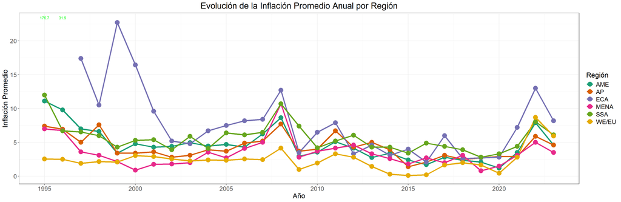

```r
# Crear el lineplot
ggplot(df_avg_inflation, aes(x = year, y = inflation, color = region, group = region)) +
    geom_line(size=1.5) +
    scale_y_continuous(limits = c(0, 23)) +
    geom_text(data = df_avg_inflation %>% filter(inflation > 23),
              aes(label = round(inflation, 1), y = 23),
              color = "green", size = 3, vjust = -0.5) +
    geom_point(size=5) +
    scale_color_brewer(palette = "Dark2") +
    labs(title = "Evolución de la Inflación Promedio Anual por Región",
         x = "Año",
         y = "Inflación Promedio",
         color = "Región")
```